# 新型冠状病毒肺炎疫情控制策略研究: 效率评估及建议

tian47720

# 疫情控制:拐点、流行时间跨度、最终规模及复工风险评估

## 受控状态及拐点

1.基本再生数（Basic Reproduction Number, $R_0$）：没有干预的情况下，在一个是全部是易感人的环境中，平均一个患者能够传染的人数。  
2.有效再生数（Effective Reproduction Number, $Reff$）：$t$ 时刻开始出现症状的一个患者平均能够传染的人数，一般以天为单位。（2020年2月5日， $Reff=0.91<1$）  
3.确诊灰度（grey degree of diagnosis, $GDD$）：实际报道的患 者总数与本文模型给出的须报道的患者总数 $R(t)$ 的比值。（2020年2月5日，$GDD=0.0$%）  
4.拐点：病例曲线继续上升，病例增长速度降低。（2020年2月7日理论拐点出现）

## 流行时间跨度、最终规模及复工风险评估

1.图1（左上）： $vEff$、$sEff$ 和 $iEff$ 分别表示疫苗的效率、对易染源和对传染源的控制效率。 而 $ctrEff$ 则是这些效率的综合结果；红线：有效再生数的上界估计；灰线：确诊灰度。  
2.图 1（右上）： $E$、$I$、$δR$ 和 $Iso$ 分别表示当时处于潜伏态、感染态、恢复态和隔离态的患者数。  
3.图 1（下）： $F$、$G$ 和 $R$ 分别表示从疫情起点到某个时间 $t$ 的处于潜伏态、感染态和恢复态的个 体总数。蓝线是模型给出的确诊患者理论值 (总数)，黑线是实际公布的确诊患者总数。 希腊字母表示 流行病学上重要的参数 (平均潜伏期、平均传染期及它们的 95% 和 99% 的置信区间值， 基本再生数 $R_0$, 非典型患者占比 $θ$ ) 以及相关的其他模型参数。此外，Seed Size 是零号患者的数目，End Size 是到 疫情结束的最终规模。

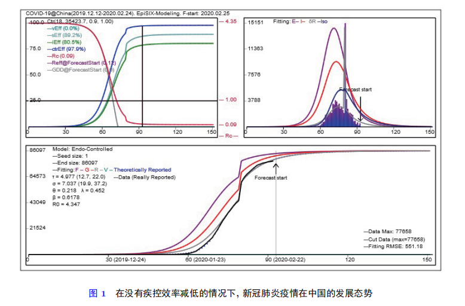

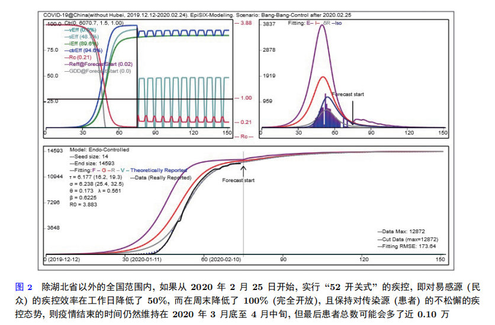

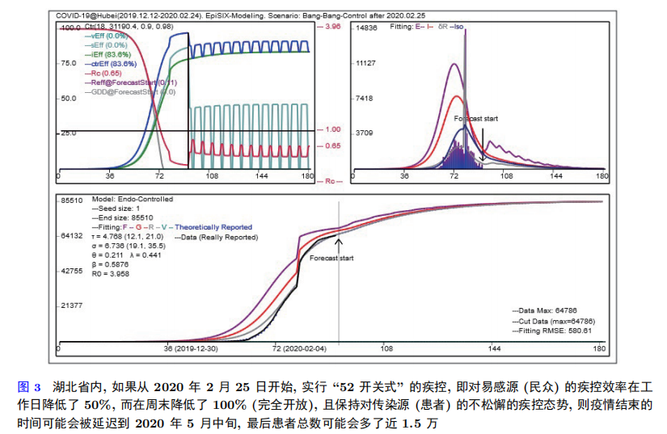